# Machine Learning Project

Andrea Ballestero

28/03/2021

## Description of the project

This is the prediction assignment writeup for the Practical Machine Learning module of the Data Science: Statistics and Machine Learning Specialization, by John Hopkins University. The goal of this project is to predict the manner in which 6 participants performed barbell lifts. The Weight Lifting Exercise Dataset source is http://web.archive.org/web/20161224072740/http:/groupware.les.inf.puc-rio.br/har

The participants of this investigation were asked to perform the barbell lifts correctly (classe A) and incorrectly in 5 different ways (classes B to E). In order to measure their performance they were asked to use accelerometers on the belt, forearm, arm and dumbell. These metrics became the features used for the analysis.

The first step was to load the datasets (one for training the model and another one for testing it).

```r
pml_training <- read_csv("pml-training.csv")
pml_testing <- read_csv("pml-testing.csv")
```

## Model building

To clean the data set and prepare it for the model building, I created another data set with the training values which did not contain NA values, and I converted the character columns to factor columns.

```r
countNA <- sapply(pml_training, function(y) sum(length(which(is.na(y)))))
countNA <- data.frame(countNA)
namesV <- rownames(countNA)
countNA <- mutate(countNA, var_names = namesV)
stay <- countNA[countNA$countNA == 0,2]

new_training <- select(pml_training, stay)
new_training <- new_training[,-c(1,3,4,5,6,7)]
new_training[sapply(new_training, is.character)] <- lapply(new_training[sapply(new_training, is.character)], as.factor)
```

## Cross validation and expected out of sample error

Then I separated the training data set into a new training set, which contained 75% of the observations, and a testing set, in order to do cross validation. Then I ran the random forest method on the training set, using the caret package. The resulting model is named “modFit”.

```r
inTrain <- createDataPartition(y=new_training$classe, p=0.75, list=FALSE)
training <- new_training[inTrain,]
testing <- new_training[-inTrain,]
modFit <- train(classe ~ .,method="rf",data=training)
```

```r
prediction <- predict(modFit, newdata = testing)
confusionMatrix(prediction, testing$classe)
```

```
## Confusion Matrix and Statistics
##
##           Reference
## Prediction    A    B    C    D    E
##          A 1393    9    0    0    0
##          B    2  934    2    0    0
##          C    0    6  851    7    2
##          D    0    0    2  795    2
##          E    0    0    0    2  897
##
## Overall Statistics
##
##                Accuracy : 0.9931
##                  95% CI : (0.9903, 0.9952)
##     No Information Rate : 0.2845
##     P-Value [Acc > NIR] : < 2.2e-16
##
##                   Kappa : 0.9912
##
##  Mcnemar's Test P-Value : NA
##
## Statistics by Class:
##
##                      Class: A Class: B Class: C Class: D Class: E
## Sensitivity            0.9986   0.9842   0.9953   0.9888   0.9956
## Specificity            0.9974   0.9990   0.9963   0.9990   0.9995
## Pos Pred Value         0.9936   0.9957   0.9827   0.9950   0.9978
## Neg Pred Value         0.9994   0.9962   0.9990   0.9978   0.9990
## Prevalence             0.2845   0.1935   0.1743   0.1639   0.1837
## Detection Rate         0.2841   0.1905   0.1735   0.1621   0.1829
## Detection Prevalence   0.2859   0.1913   0.1766   0.1629   0.1833
## Balanced Accuracy      0.9980   0.9916   0.9958   0.9939   0.9975
```

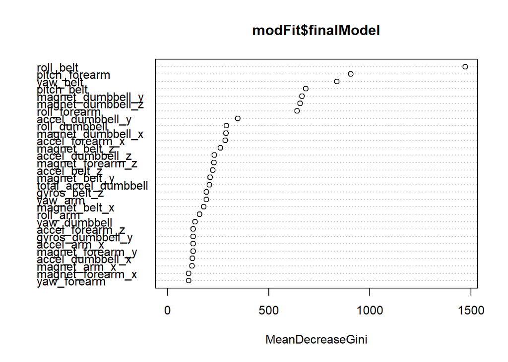

```r
varImpPlot(modFit$finalModel, sort = TRUE)
```

As seen on the following graph, roll_belt was the most important variable on the data set, clearly dividing the values in two big groups:

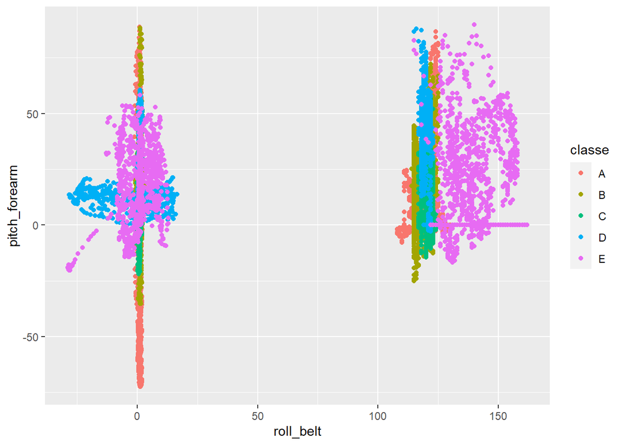

```r
qplot(roll_belt, pitch_forearm, col = classe, data = training)
```

## Prediction of 20 test cases

```r
predictionFinal <- predict(modFit, newdata = pml_testing)
predictionFinal
```

```
##  [1] B A B A A E D B A A B C B A E E A B B B
## Levels: A B C D E
```

I also plotted the random forest following a guide created by https://shiring.github.io/machine_learning/2017/03/16/rf_plot_ggraph

## Tree graph

[figure not shown]

```r
tree_func <- function(final_model,
                      tree_num) {

  # get tree by index
  tree <- randomForest::getTree(final_model,
                                k = tree_num,
                                labelVar = TRUE) %>%
    tibble::rownames_to_column() %>%
    # make leaf split points to NA, so the 0s won't get plotted
    mutate(`split point` = ifelse(is.na(prediction), `split point`, NA))

  # prepare data frame for graph
  graph_frame <- data.frame(from = rep(tree$rowname, 2),
                            to = c(tree$`left daughter`, tree$`right daughter`))

  # convert to graph and delete the last node that we don't want to plot
  graph <- graph_from_data_frame(graph_frame) %>%
    delete_vertices("0")

  # set node labels
  V(graph)$node_label <- gsub("_", " ", as.character(tree$`split var`))
  V(graph)$leaf_label <- as.character(tree$prediction)
  V(graph)$split <- as.character(round(tree$`split point`, digits = 2))

  # plot
  plotFinal <- ggraph(graph, 'dendrogram') +
    theme_bw() +
    geom_edge_link() +
    geom_node_point() +
    geom_node_text(aes(label = node_label), na.rm = TRUE, repel = TRUE) +
    geom_node_label(aes(label = split), vjust = 2.5, na.rm = TRUE, fill = "white") +
    geom_node_label(aes(label = leaf_label, fill = leaf_label), na.rm = TRUE,
                    repel = TRUE, colour = "white", fontface = "bold", show.legend = FALSE) +
    theme(panel.grid.minor = element_blank(),
          panel.grid.major = element_blank(),
          panel.background = element_blank(),
          plot.background = element_rect(fill = "white"),
          panel.border = element_blank(),
          axis.line = element_blank(),
          axis.text.x = element_blank(),
          axis.text.y = element_blank(),
          axis.ticks = element_blank(),
          axis.title.x = element_blank(),
          axis.title.y = element_blank(),
          plot.title = element_text(size = 18))

  print(plotFinal)
}

tree_func(modFit$finalModel, 2)
```